# R Notebook

[output not shown]

Using the orchard plot in Figure 1), we can visualise the distribution and precision of the effect size calculated, lnRR. The effect sizes appear to be approximately clustered around 0, which could suggests there’s not a large difference in the response to the treatment relative to the control. We can see that there is a few studies with a large positive effect size.

To visually assess the possibility of publication bias, create funnel plot of data

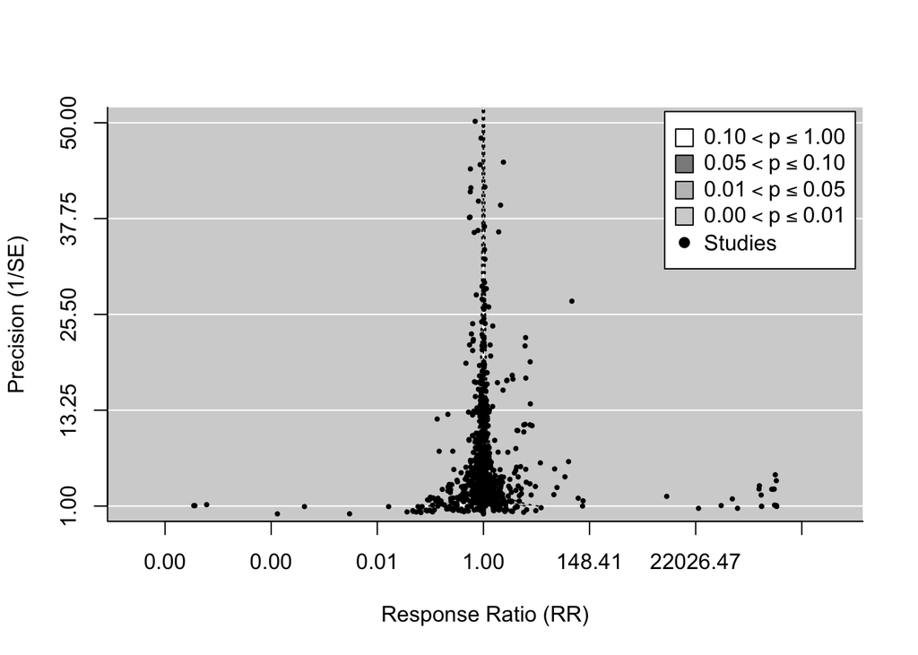

Figure 2: Funnel plot depicting the response ratio of treatment to control as a function of precision (1/SE)

To visualise the different effect sizes over time, use Time-lag plot

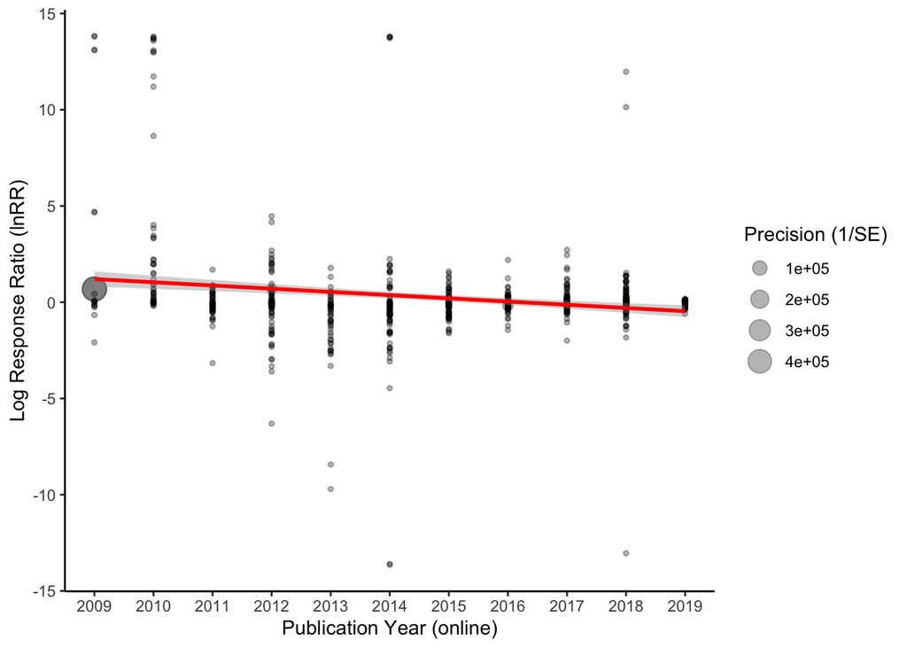

Figure 3: Plot of lnRR as function of publication year. Points are scaled in relation to their precision (1/sqrt(var_lnRR)). Small points idicate effects with low precision or high sampling variance

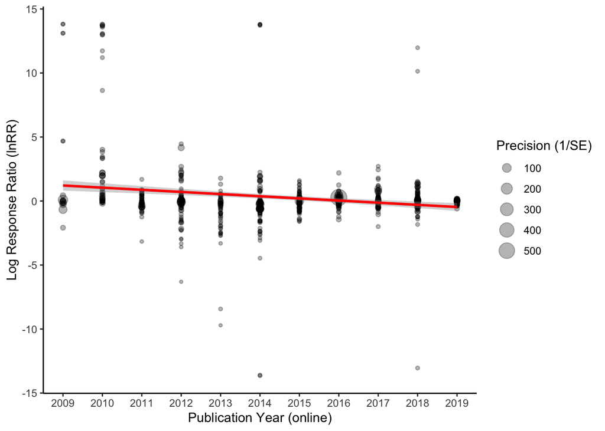

Figure 4: Plot of lnRR as function of publication year. Data points with sampling variance smaller than 10<sup>-9</sup> were removed to visualise the difference in precision between the remaining studies. Points are scaled in relation to their precision (1/sqrt(var_lnRR)). Small points idicate effects with low precision or high sampling variance

To test for time lag bias, meta-regression model with publication year as a fixed effect

```r
MLMA_year <- metafor::rma.mv(yi = LRR ~ Year.online,
                        # effect size measure log response ratio with year as fixed effect
                              V = var_LRR, # sampling variance of LRR
# fit model using restricted maximum likelihood (considers degrees freedom, better for small sample sizes)
                              method = "REML",
                              # random-effects of the model study and observation (residual)
                              random = list(~1 | Study,
                                            ~1 | residual
                                            #, ~1 | Species
                                            ),
                              test = "t", # use the t test statistic
                              data = lnRR_data)

summary(MLMA_year)
```

```
Multivariate Meta-Analysis Model (k = 795; method: REML)

    logLik    Deviance         AIC         BIC        AICc
-1782.8090   3565.6180   3573.6180   3592.3213   3573.6688

Variance Components:

            estim    sqrt  nlvls  fixed    factor
sigma^2.1  0.4017  0.6338     91     no     Study
sigma^2.2  4.0496  2.0124    795     no  residual

Test for Residual Heterogeneity:
QE(df = 793) = 128790282.9931, p-val < .0001

Test of Moderators (coefficient 2):
F(df1 = 1, df2 = 793) = 7.6505, p-val = 0.0058

Model Results:

             estimate       se     tval   df    pval    ci.lb     ci.ub
intrcpt      231.0645  83.4908   2.7675  793  0.0058  67.1755  394.9536  **
Year.online   -0.1146   0.0414  -2.7660  793  0.0058  -0.1959   -0.0333  **

---
Signif. codes:  0 '***' 0.001 '**' 0.01 '*' 0.05 '.' 0.1 ' ' 1
```

```r
pred_year <- predict(MLMA_year)[1]
pred_year
```

```
    pred     se  ci.lb  ci.ub   pi.lb  pi.ub
1 0.8173 0.2705 0.2862 1.3483 -3.3581 4.9927
```

```r
r2_time <- r2_ml(MLMA_year)
r2_time_flex <- flextable(tibble("R2 marginal" = r2_time[1], "R2 conditional" = r2_time[2]))
r2_time_flex <- set_caption(r2_time_flex,
            caption = "Variation in effect size explained by year and random effects of the model")
r2_time_flex
```

Table 3: Variation in effect size explained by year and random effects of the model

| R2 marginal | R2 conditional |
| --- | --- |
| 0.02265587 | 0.1108595 |

```r
MLMA_inverse <- metafor::rma.mv(yi = LRR ~ 1/var_LRR,
                        # effect size measure log response ratio with inverse sampling variance as fixed effect
                              V = var_LRR, # sampling variance of LRR
# fit model using restricted maximum likelihood (considers degrees freedom, better for small sample sizes)
                              method = "REML",
                              # random-effects of the model study and observation (residual)
                              random = list(~1 | Study,
                                            ~1 | residual
                                          #  , ~1 | Species
                                            ),
                              test = "t", # use the t test statistic
                              data = lnRR_data)

summary(MLMA_inverse)
```

```
Multivariate Meta-Analysis Model (k = 795; method: REML)

    logLik    Deviance         AIC         BIC        AICc
-1788.4810   3576.9621   3582.9621   3596.9933   3582.9925

Variance Components:

            estim    sqrt  nlvls  fixed    factor
sigma^2.1  0.4792  0.6922     91     no     Study
sigma^2.2  4.0497  2.0124    795     no  residual

Test for Heterogeneity:
Q(df = 794) = 736088678.9542, p-val < .0001

Model Results:

estimate      se    tval   df    pval    ci.lb   ci.ub
  0.1273  0.1140  1.1162  794  0.2647  -0.0966  0.3512

---
Signif. codes:  0 '***' 0.001 '**' 0.01 '*' 0.05 '.' 0.1 ' ' 1
```

```r
r2_inverse <- r2_ml(MLMA_inverse)
r2_inverse_flex <- flextable(tibble("R2 marginal" = r2_inverse[1],
       "R2 conditional" = r2_inverse[2]))

r2_inverse_flex <- set_caption(r2_inverse_flex,
            caption = "Variation in effect size explained by the inverse sampling variance and random effects of the model")
r2_inverse_flex
```

Table 4: Variation in effect size explained by the inverse sampling variance and random effects of the model

| R2 marginal | R2 conditional |
| --- | --- |
| 0 | 0.1058073 |

[output not shown]

Table 5: Variation in the effect size explained by species effects and random effects of the model

| R2 marginal | R2 conditional |
| --- | --- |
| 0.02815814 | 0.9523042 |

#### The potential for publication bias, based on the meta-regression results

There appears to potentially be a time-lag bias present in the data. In Figure 3) we can see that in the first two years, 2009 and 2010, there are more studies with a higher effect size (lnRR) than in later years.